# Magolego SNA - Lab 5

Danil Gizdatullin, Evgenij Tsymbalov, Andrey Shestakov

05/15/2015

```r
library('igraph')
```

**TO SAVE YOUR TIME, PLEASE START DOWNLOADING [THIS](https://www.cs.upc.edu/~csn/lab/wikipedia.gml) NETWORK RIGHT NOW**

## Cohesive subgraphs

### Graph cliques

Graph clique is a subset of vertices of a graph such that every two vertices in the clique are adjacent.

How many cliques can you see on this graph?

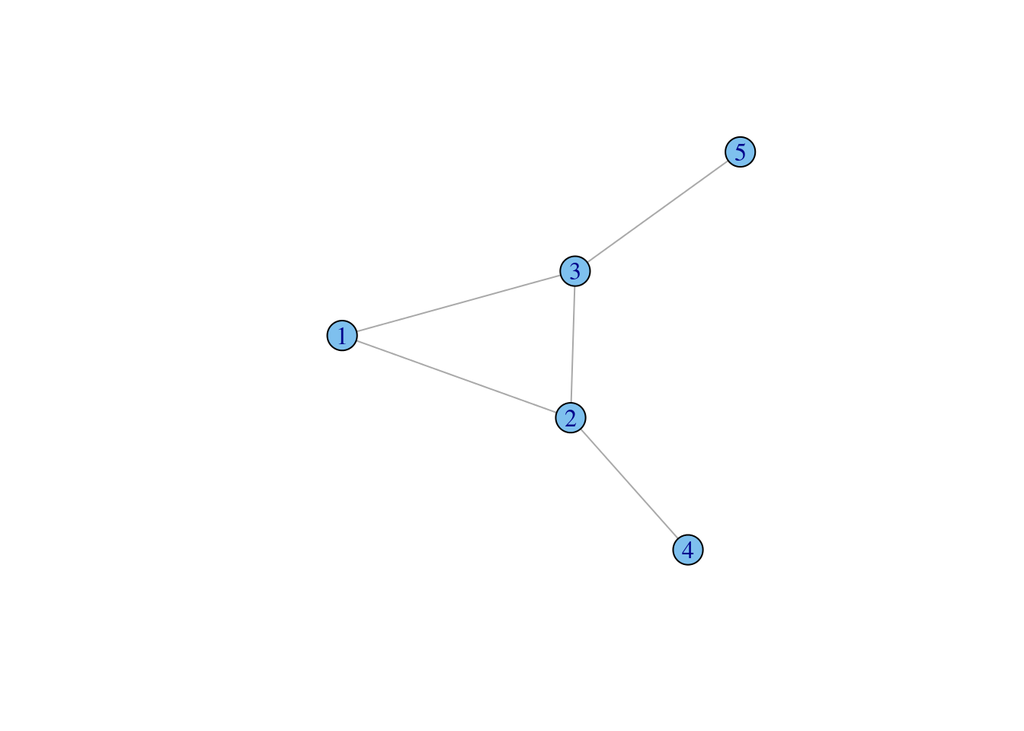

```r
plot(graph.famous("bull"))
```

There was a couple of definitions about the cliques in graph on the lecture.

And, finally, **graph clique number** is the size of the maximum clique. Bull graph’s clique number is 3.

```r
maximal.cliques(graph.famous("bull"))
```

```
## [[1]]
## [1] 4 2
##
## [[2]]
## [1] 5 3
##
## [[3]]
## [1] 1 2 3
```

Let’s demonstrate some useful functions for finding cliques. Our graph today is again Zachary’s Karate Club graph:

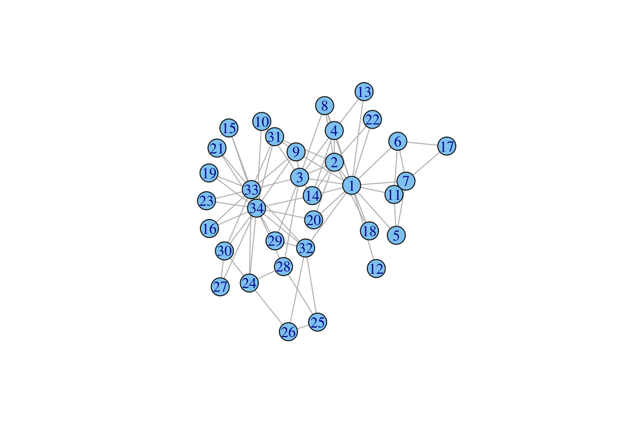

```r
g = graph.famous("Zachary")
plot(g)
```

We can define sizes of maximal cliques we interested in:

```r
maximal.cliques(g, min = 4, max = 5) # maximal cliques of sizes 4 and 5
```

```
## [[1]]
## [1] 24 34 33 30
##
## [[2]]
## [1] 34  9 33 31
##
## [[3]]
## [1] 2 1 4 3 8
##
## [[4]]
## [1]  2  1  4  3 14
```

`maximal.cliques` returns lists of vertices - maximal cliques. `clique.number` returns graph’s clique number.

Let’s find and show maximal cliques for Zachary Carate Club graph: `lrg = largest.cliques(g)` returns ids of nodes - largest cliques

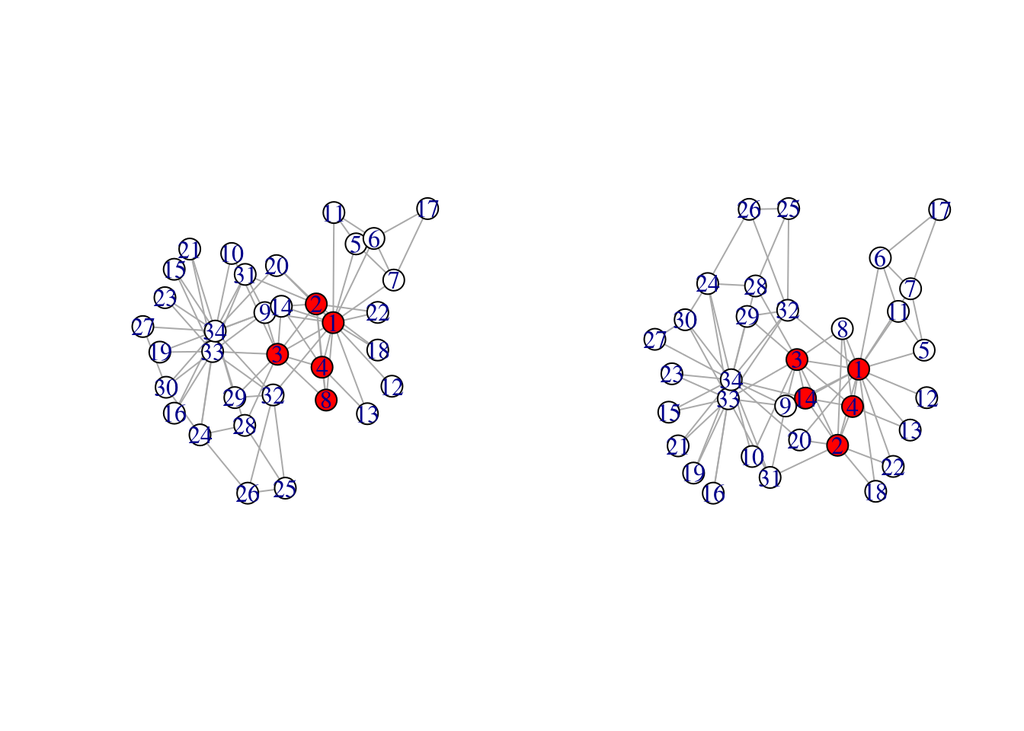

```r
largest = largest.cliques(g)

op = par(mfrow = c(1,2))

labels = rep(0, vcount(g))

labels[largest[[1]]] = 2
plot(g, vertex.color = labels)
labels = rep(0, vcount(g))
labels[largest[[2]]] = 2
plot(g, vertex.color = labels)
```

```r
par(op)
```

### k-core

**k-core** is a maximal subset of vertices such that each is connected to at least k others in the subset.

R has a function wich calculates the *coreness* for each vertex. The coreness of a vertex is k if it belongs to the k-core but not to the (k+1)-core.

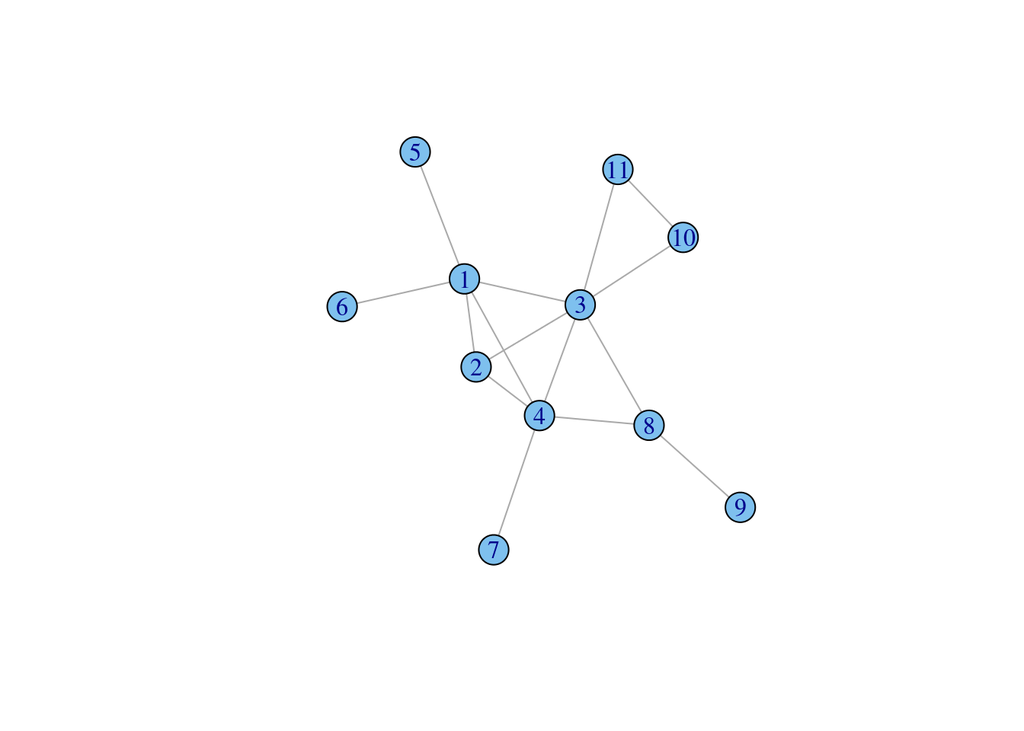

```r
# Let's make some graph
z<-graph.empty(n=11, directed = FALSE)
z <- add.edges(z,c(1,2, 1,3, 1,4, 1,6, 1,5, 2,3, 2,4, 3,10, 3,11, 3,8, 3,4, 4,8, 4,7, 8,9, 10,11))
plot(z)
```

Now we find maximum k-core and pick out it on graph

```r
coreness <- graph.coreness(z)
max_cor <- max(coreness)
max_cor
```

```
## [1] 3
```

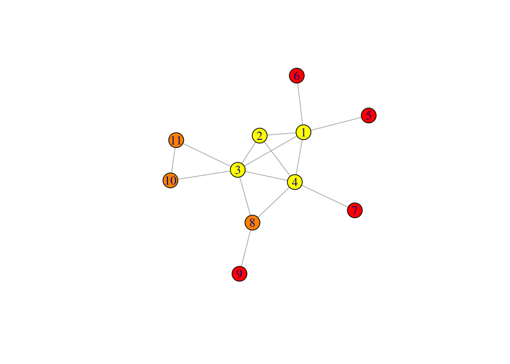

```r
color_bar <- heat.colors(max_cor)
plot(z, vertex.color = color_bar[coreness])
```

## Community detection

### The list of community detection algorithms in igraph

- `edge.betweenness.community` [Newman and Girvan, 2004]
- `fastgreedy.community` [Clauset et al., 2004] (modularity optimization method)
- `label.propagation.community` [Raghavan et al., 2007]
- `leading.eigenvector.community` [Newman, 2006]
- `multilevel.community` [Blondel et al., 2008] (the Louvain method)
- `optimal.community` [Brandes et al., 2008]
- `spinglass.community` [Reichardt and Bornholdt, 2006]
- `walktrap.community` [Pons and Latapy, 2005]
- `infomap.community` [Rosvall and Bergstrom, 2008]

### Newman-Girvan Edge-Betweenness

#### Edge betweenness

**Edge betweenness** is equal to the number of shortest paths from all vertices to all others that pass through that edge.

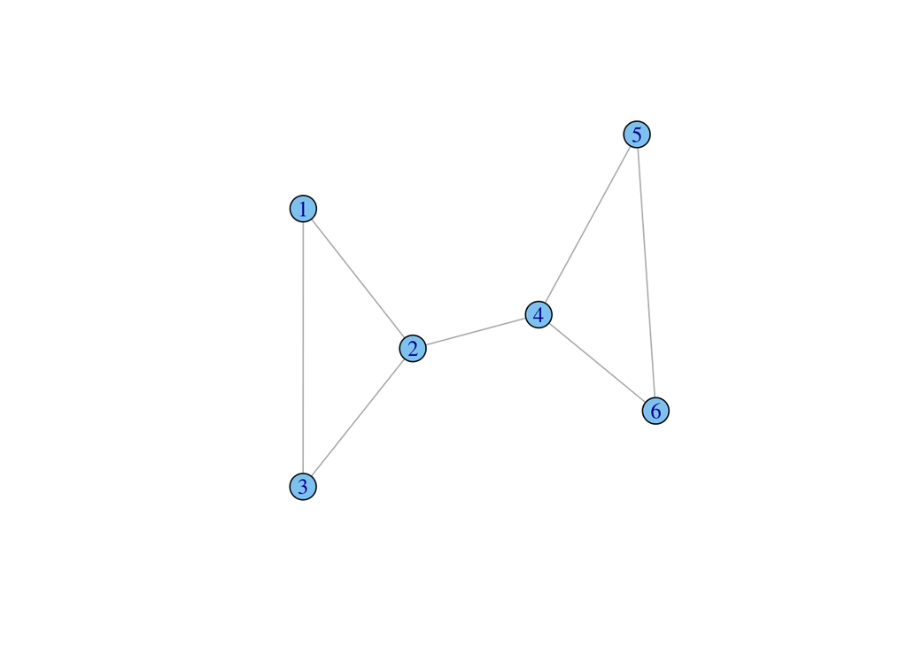

```r
g<-graph.empty(n=6, directed = FALSE)
g <- add.edges(g,c(1,2, 2,3, 1,3, 2,4, 4,5, 4,6, 5,6))
plot(g)
```

```r
betw <- edge.betweenness(g)
#E(g)
#betw
```

#### The algorithm

The Newman-Girvan algorithm detects communities by progressively removing edges from the original network. The Girvan-Newman algorithm focuses on edges that are most likely “between” communities.

Algorithm:

- **Step 1**: the betweenness of all existing edges in the network is calculated first.
- **Step 2**: the edge with the highest betweenness is removed.
- **Step 3**: the betweenness of all edges affected by the removal is recalculated.
- **Step 4**: steps 2 and 3 are repeated until no edges remain.

The best partition is selected based on modularity.

There is edge.betweenness.community function in R

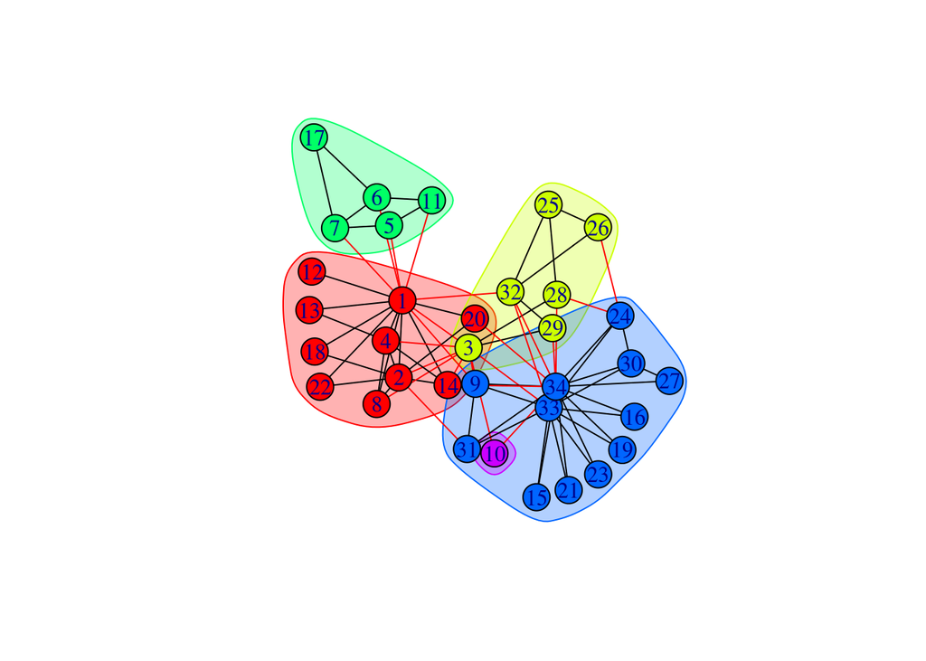

```r
g <- graph.famous("Zachary")
eb <- edge.betweenness.community(g)
plot(eb, g)
```

```r
## A bit more hand-made way
# color_map = c("grey","blue","black","yellow","red","green")
# membership = cutat(eb, no = 4)
# membership = eb$membership
# plot(g, vertex.color = eb$membership)
```

Also you can obtain dendrogram:

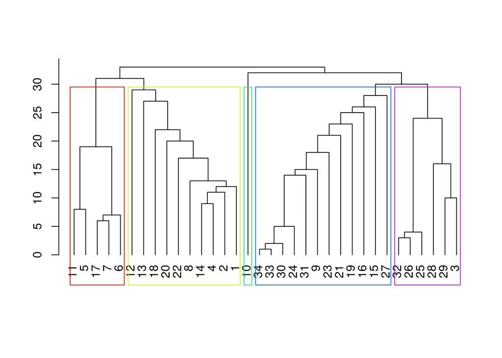

```r
dendPlot(eb, mode="hclust", rect = 5)
```

```r
## Optionally you can run this
# dend <- as.dendrogram(eb)
# plot(dend)
```

### Greedy Modularity maximization

Alternatively to the previous method, this one is agglomerative. Intially consider a network s.t. * There is no edges * All clusters consist of a single vertex

Iteratively add an edge that delivers maximum modularity gain and merge correspondent communitues.

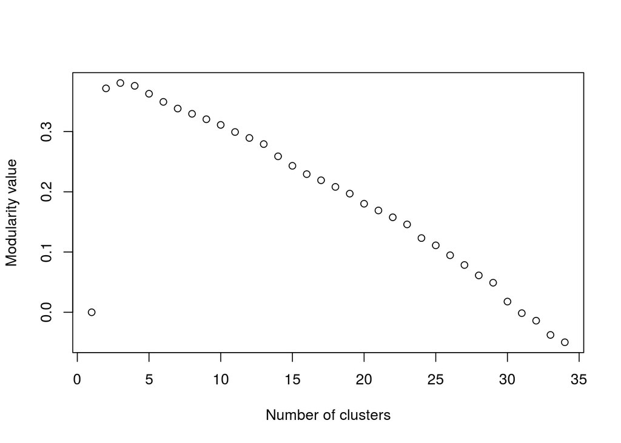

```r
g <- graph.famous(name = "Zachary")
mm <- fastgreedy.community(g)

plot(rev(mm$modularity), xlab = 'Number of clusters', ylab = 'Modularity value')
```

```r
which.max(rev(mm$modularity))
```

```
## [1] 3
```

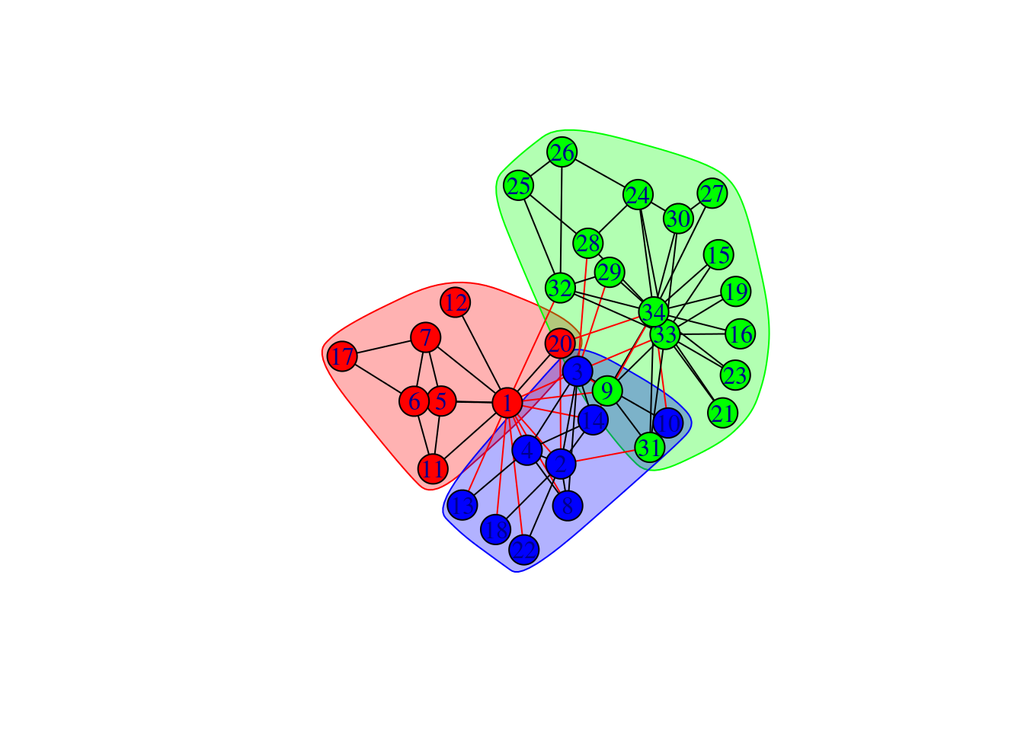

```r
plot(mm, g)
```

### Label propagation

Label propagation algorithm consists of four steps:

- **Step 1**: Initialize labels
- **Step 2**: Randomize node ordering
- **Step 3**: For every node replace its label with occurring with the highest frequency among neighbors
- **Step 4**: Repeat steps 2-3 until every node will have a label that the maximum number of its neighbors have

Warning! Due to **step 2** you may get different results.

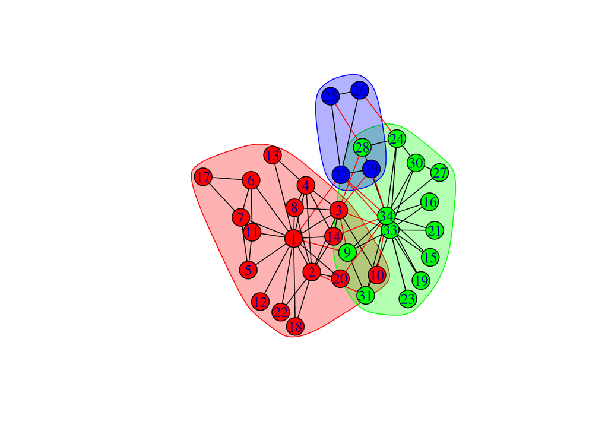

```r
g <- graph.famous("Zachary")
lp <- label.propagation.community(g)
plot(lp, g)
```

### Wikipedia example

Load wikipedia network in R and run some community detection algorithm. Extract article names in some communities and check whether they make sense?

```r
g <- read.graph('wikipedia.gml', format = 'gml')
g <- as.undirected(g)
```

The next lines of code might be usefull for interpretation

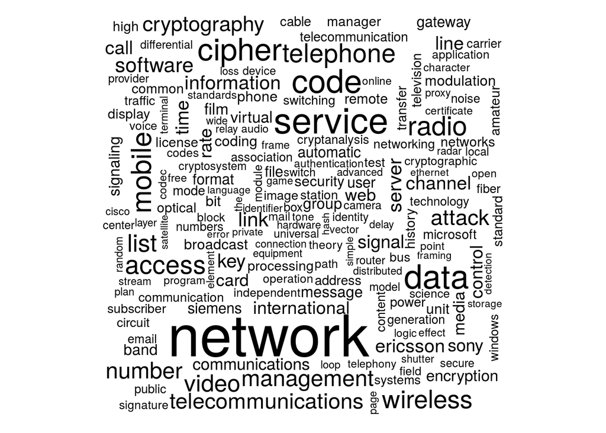

```r
mm <- fastgreedy.community(g)
l <- V(g)$label[mm$membership == 2]
text <- paste(l, collapse = ' ')

#install.packages(c("tm", "SnowballC", "wordcloud", "RColorBrewer", "XML"))

library(wordcloud)
wordcloud(text, type="text",
        lang="english", excludeWords = NULL,
        textStemming = FALSE,  colorPalette="Dark2",
        max.words=200)
```